# Collating Metadata

Augustus Pendleton

26 June, 2025

# Purpose of this document

The previous three steps worked to clean our 16S data, assign taxonomy, remove contamination and assess accuracy. In the next steps, we start generating actual “results”, including measures of alpha diversity and beta diversity. It will be necessary for us to correlate these measures to metadata we’ve collected (stored in our centralized metadata logs) as well as the various chemical and physical measures collected by the EPA. This will require the curation, cleaning, and joining of numerous data streams, and will also result in figures relevant to the paper, including CTD profiles, PCAs between sites, and mapping set-ups.

## Loading our current metadata

```r
# Efficiently load packages
pacman::p_load(phyloseq, iNEXT, tidyverse, readxl, ggpubr, scales, patchwork, install = FALSE)

knitr::write_bib(file = "data/05_metadata_exports/packages.bib")

source("code/R/plotting_aesthetics.R")

load("data/04_cytometry_exports/meta_with_ccs.RData")

meta_track2 <- meta_with_ccs %>%
    mutate(Depth_Class = factor(Depth_Class, levels = c("E","M","B")),
         Depth_Range = case_when(Deployment_Depth_m <=10 ~ "< 10 m",
                               Deployment_Depth_m <=20 ~ "10-20 m",
                               Deployment_Depth_m <=30 ~ "20-30 m",
                               Deployment_Depth_m <=40 ~ "30-40 m",
                               Deployment_Depth_m <=100 ~ "40-100 m",
                               Deployment_Depth_m >100 ~ ">100 m"),
         Depth_Range = factor(Depth_Range, levels = c("< 10 m", "10-20 m","20-30 m", "30-40 m", "40-100 m",">100 m")))
```

## Bringing in SeaBird CTD Data

CTD data was shared with us from the EPA and the raw files live in AAH_ONT_2023/External_Data/202305_SeabirdData and AAH_ONT_2023/External_Data/202310_SeabirdData. Descriptions of how those data were accessed, cleaned, and converted to dataframe compatible csvs are described in AAH_ONT_2023/External_Data/Cleaning_CNV_Files.R. Note that anomalous and extreme negative conductivity values at one or two depths would cause parsing issues for each sample; as such, these values were manually removed in a text editor before being read into R.

```r
may_ctd <- read_csv("data/05_metadata_exports/SeabirdData/202305_SeabirdData/Combined_CTD_Data_OurStations.csv")

sep_ctd <- read_csv("data/05_metadata_exports/SeabirdData/202310_SeabirdData/Combined_CTD_Data_OurStations.csv")

may_other_ctd <- read_csv("data/05_metadata_exports/SeabirdData/202305_SeabirdData/Combined_CTD_Data_OtherStations.csv")

sep_other_ctd <- read_csv("data/05_metadata_exports/SeabirdData/202310_SeabirdData/Combined_CTD_Data_OtherStations.csv")
```

## Bringing in EPA Chem Analyses

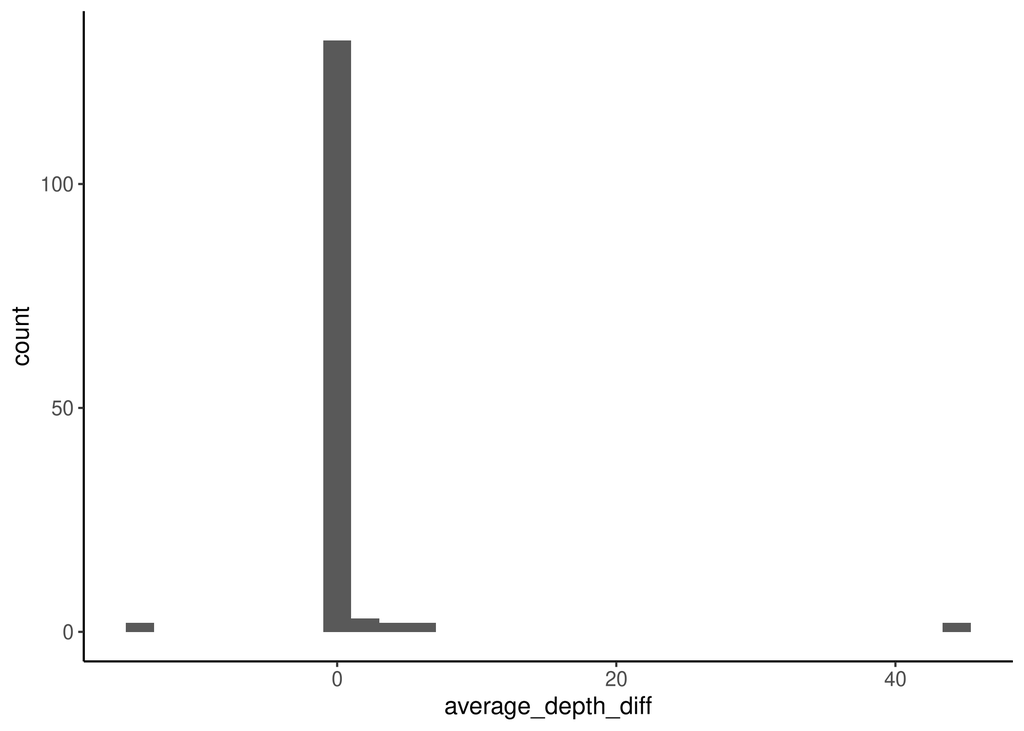

```r
minimum_detection_limits <- read_excel("data/05_metadata_exports/2023_LakeOntario_ChemWQ_Final.xlsx", sheet = "detection limits") %>%
  slice_head(n = 1) %>%
  select(where(is.numeric)) %>%
  pivot_longer(everything(), names_to = "Variable", values_to = "MDL") %>%
  separate_wider_delim(Variable, names = c("Variable", "Unit"), delim = " ", too_many = "merge") %>%
  mutate(Unit = str_trim(Unit))

epa_chem <- read_excel("data/05_metadata_exports/2023_LakeOntario_ChemWQ_Final.xlsx", sheet = "DetLimitCorr") %>%
  mutate(Depth_Class = case_when(`Depth Strata` == "Epi" ~ "E",
                                 `Depth Strata` == "Hypo/B2" ~ "B",
                                 `Depth Strata`%in%c("Fmax","Mid") ~ "M"), # Convert their Depth Strata to our Depth classes
         Depth_Class = factor(Depth_Class, levels = c("E","M","B")),
         Site = as.character(Site)) %>% # Convert station to character
  select(month = Month, Station_ID = Site, Chem_Depth = `Separate depths (m)`, Depth_Class, is_Fmax = `Fmax seen?`, is_stratified = `Stratified/ Unstratified?`, `NH4 ug N/L`:`chl-a    ug/L`, EPA_Comments = Comments) %>%
  filter(!is.na(Station_ID)) %>%
  mutate(across(`NH4 ug N/L`:`chl-a    ug/L`, as.numeric)) %>%
  pivot_longer(`NH4 ug N/L`:`chl-a    ug/L`, names_to = "Variable", values_to = "Variable_Value") %>%
   filter(!is.na(Variable_Value)) %>%
   separate_wider_delim(Variable, names = c("Variable", "Unit"), delim = " ", too_many = "merge") %>%
  mutate(Unit = str_trim(Unit))

epa_units <- epa_chem %>%
  select(Variable, Unit) %>%
  unique()

write_csv(epa_units, file = "data/05_metadata_exports/units.csv")

clean_epa_chem <- epa_chem %>%
  select(-Unit) %>%
  pivot_wider(names_from = "Variable", values_from = "Variable_Value") %>%
  janitor::clean_names(case = "none") %>%
  mutate(Station_ID = as.numeric(Station_ID)) %>%
  mutate(SRP = ifelse(SRP < 30, SRP, NA))


epa_chem_for_microbe_mapper <- clean_epa_chem %>%
  filter(month != "July", Depth_Class != "M") %>%
  mutate(Depth_Class = ifelse(Depth_Class == "E", "Surface","Bottom")) %>%
  select(month, Station_ID, Depth_Class, NH4:chl_a)

save(clean_epa_chem, file = "data/05_metadata_exports/clean_epa_chem.RData")

# There was one NA from MAy St. 42 for chlorophyll - in the data log, it's annotated as "broken"

# Join with metatrack2
meta_track3 <- meta_track2 %>%
  left_join(clean_epa_chem) # Join chlorophyll and doc

# Make sure chlorophyll depth matches
meta_track3 %>%
  mutate(average_depth_diff = Chem_Depth - Deployment_Depth_m) %>% # Check how far off their recorded depth was to ours
  ggplot(aes(x = average_depth_diff)) +
  geom_histogram()
```